# Example: Influenza in Sweway

## Introduction

The public health institute of Sweway is investigating an outbreak of influenza in the country. This document is a worked example of using the `seirvax` package to simulate the spread of the disease and to evaluate potential intervention strategies. It follows the course an investigation might take: looking at the early case data, estimating how fast the outbreak is growing, building a transmission model, fitting it to what has been observed, and projecting forward under different measures.

All information in this document is fake and intended for a pandemic preparedness exercise. Sweway is one of four fictional countries bundled with the package, each with five regions and population by five-year age band.

This document works end to end on one outbreak. The scripts in [`examples/`](https://github.com/Gulfa/modelling_prep_ex/tree/main/examples) take the same features one at a time, and are the place to look for the details behind each step:

| [`01_single_population.R`](https://github.com/Gulfa/modelling_prep_ex/blob/main/examples/01_single_population.R) | one population, deterministic and stochastic runs, plot styles |
| --- | --- |
| [`02_age_structured.R`](https://github.com/Gulfa/modelling_prep_ex/blob/main/examples/02_age_structured.R) | age mixing, susceptibility, severity and vaccine effectiveness by age |
| [`03_age_and_region.R`](https://github.com/Gulfa/modelling_prep_ex/blob/main/examples/03_age_and_region.R) | combining age and region mixing, seeding, interventions over time |
| [`04_scenarios.R`](https://github.com/Gulfa/modelling_prep_ex/blob/main/examples/04_scenarios.R) | comparing several scenarios with `compare_scenarios()` |
| [`05_fitting.R`](https://github.com/Gulfa/modelling_prep_ex/blob/main/examples/05_fitting.R) | the three fitting methods, priors, diagnostics and projections |
| [`06_country_data.R`](https://github.com/Gulfa/modelling_prep_ex/blob/main/examples/06_country_data.R) | the bundled country data, distances and maps |
| [`07_line_list_exercise.R`](https://github.com/Gulfa/modelling_prep_ex/blob/main/examples/07_line_list_exercise.R) | generating exercise data and fitting R0 back from it |
| [`08_vaccination.R`](https://github.com/Gulfa/modelling_prep_ex/blob/main/examples/08_vaccination.R) | what each vaccine effect does, coverage needed, targeting doses and timing campaigns |

[`docs/model_description.md`](https://github.com/Gulfa/modelling_prep_ex/blob/main/docs/model_description.md) has the equations and assumptions, and [`docs/data.md`](https://github.com/Gulfa/modelling_prep_ex/blob/main/docs/data.md) describes the bundled data.

The exercise uses the following geographical data:

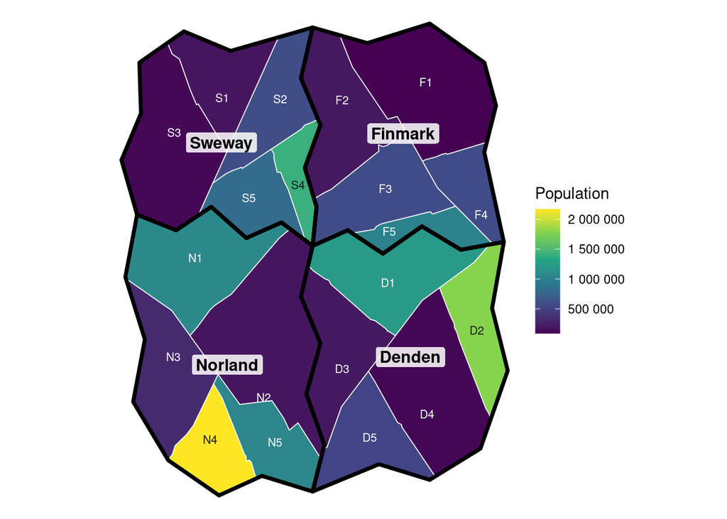

Figure 1: The regions of Sweway and its neighbours, shaded by population.

```r
library(seirvax)   # devtools::load_all() instead when working on the package

library(ggplot2)
library(dplyr)
library(data.table)

plot_region_map()
```

## Early outbreak

Early in an outbreak the available data is thin. Here it is a line list of about 1,250 individual cases: everyone admitted to hospital (around 200 of them) or who died, plus a tenth of the milder infections that happened to be detected. Each row is one case, with the dates of symptom onset, hospital admission and death where they apply, along with the patient’s age group and region.

The outbreak is generated with a fixed seed, so every figure and number in this document is reproducible; drop `seed` from the call below for a different one.

```r
ll <- simulate_line_list(t_max = 30, n_seed = 30, R0 = 1.4, seed = 1)
head(ll)
```

```
   id date_onset age_group age_mid region vaccinated hospitalised date_hospital
1:  1 2026-01-02     20-24    22.5     S1      FALSE        FALSE          <NA>
2:  2 2026-01-02     60-64    62.5     S1      FALSE        FALSE          <NA>
3:  3 2026-01-03     45-49    47.5     S4      FALSE        FALSE          <NA>
4:  4 2026-01-03     25-29    27.5     S1      FALSE        FALSE          <NA>
5:  5 2026-01-03     45-49    47.5     S4      FALSE        FALSE          <NA>
6:  6 2026-01-04     45-49    47.5     S2      FALSE         TRUE    2026-01-05
    died date_death
1: FALSE       <NA>
2: FALSE       <NA>
3: FALSE       <NA>
4: FALSE       <NA>
5: FALSE       <NA>
6: FALSE       <NA>
```

Counting cases by onset date gives the epidemic curve so far:

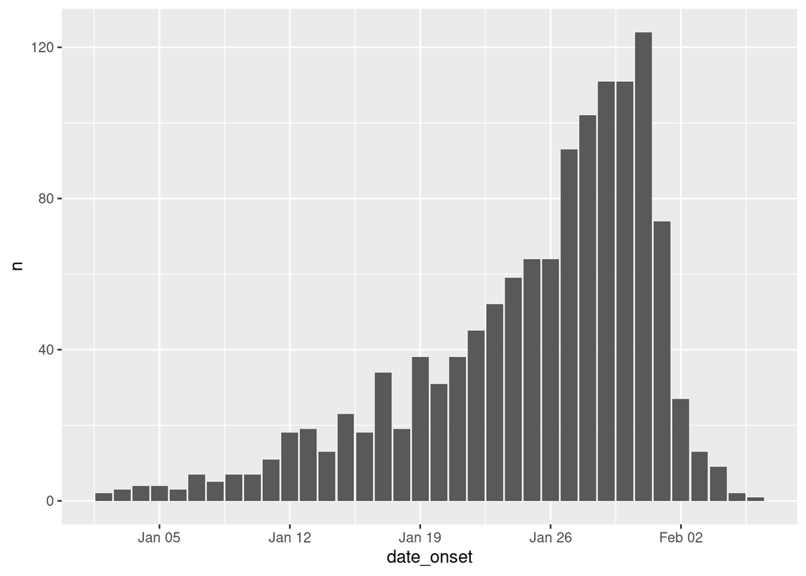

Figure 2: Detected cases by date of symptom onset.

```r
ll %>% group_by(date_onset) %>% summarise(n = n()) %>%
  ggplot(aes(x = date_onset, y = n)) +
  geom_col()
```

### Growth rate

Before building a transmission model, a simple regression tells us how fast the outbreak is growing. Hospital admissions are the most reliable series in the line list, since every admission is detected, so we fit a Poisson regression of daily admissions against date. The coefficient on date is the exponential growth rate, and `log(2)` divided by it is the doubling time.

```r
hosp_inc <- as.data.frame(ll %>% filter(hospitalised == TRUE) %>%
                            group_by(date_hospital) %>% summarise(I = n()))

fit <- glm(I ~ date_hospital, data = hosp_inc, family = poisson)
summary(fit)
```

```
Call:
glm(formula = I ~ date_hospital, family = poisson, data = hosp_inc)

Coefficients:
                Estimate Std. Error z value Pr(>|z|)
(Intercept)   -2.294e+03  2.248e+02  -10.20   <2e-16 ***
date_hospital  1.121e-01  1.098e-02   10.21   <2e-16 ***
---
Signif. codes:  0 '***' 0.001 '**' 0.01 '*' 0.05 '.' 0.1 ' ' 1

(Dispersion parameter for poisson family taken to be 1)

    Null deviance: 147.66  on 26  degrees of freedom
Residual deviance:  20.18  on 25  degrees of freedom
AIC: 118.74

Number of Fisher Scoring iterations: 4
```

```r
ci <- confint(fit)[2, ]
print(glue::glue("Growth rate estimate: {round(coef(fit)[2], 3)} ",
                 "(95% CI: {round(ci[1], 3)} - {round(ci[2], 3)})"))
```

```
Growth rate estimate: 0.112 (95% CI: 0.091 - 0.134)
```

```r
print(glue::glue("Doubling time estimate: {round(log(2) / coef(fit)[2], 3)} days"))
```

```
Doubling time estimate: 6.182 days
```

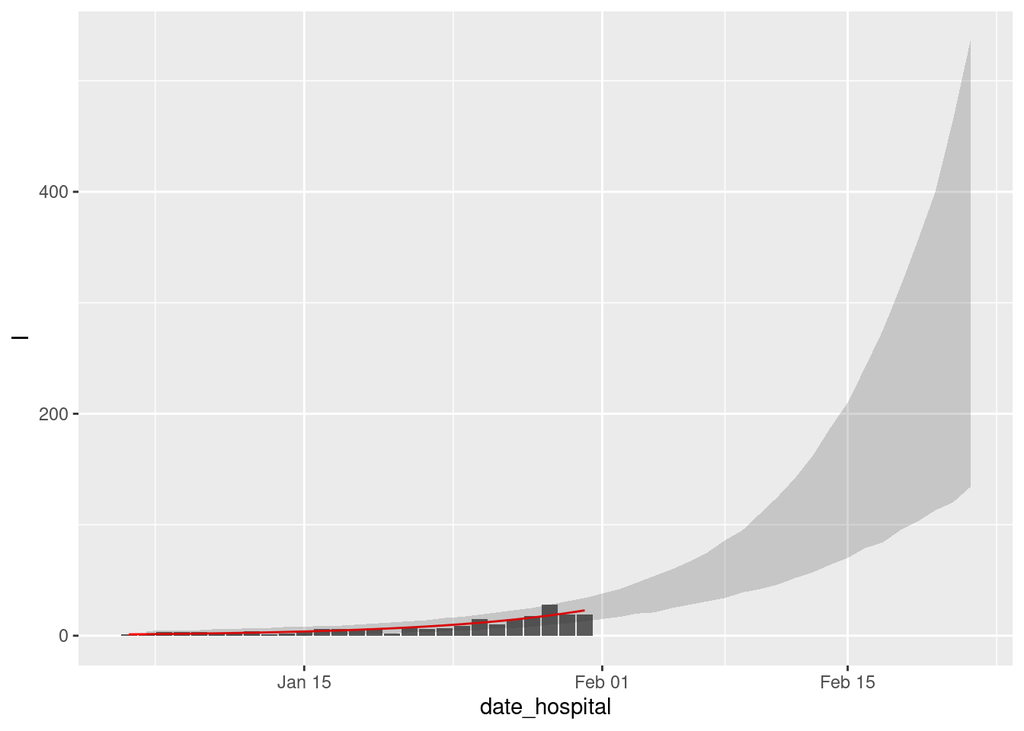

Figure 3: Daily hospital admissions with the fitted exponential growth and a 95% prediction interval extrapolated three weeks ahead.

```r
preds <- ciTools::add_pi(
  data.frame(date_hospital = hosp_inc$date_hospital[1] + 1:(nrow(hosp_inc) + 3 * 7),
             I = 0),
  fit = fit, level = 0.95, names = c("lwr", "upr"))

ggplot(hosp_inc, aes(x = date_hospital, y = I)) +
  geom_col() +
  geom_line(aes(y = predict(fit, type = "response")), color = "red") +
  geom_ribbon(data = preds, aes(ymin = lwr, ymax = upr), alpha = 0.2)
```

This extrapolation assumes the growth continues unchanged, which is only reasonable for a short horizon: it has no way to represent the depletion of susceptible people, nor the effect of any measures taken. That is what the transmission model below is for.

### Who is affected

The line list also shows which age groups and regions the cases are in. This matters both for targeting measures and, later, for checking whether the model’s assumptions about severity and mixing are plausible.

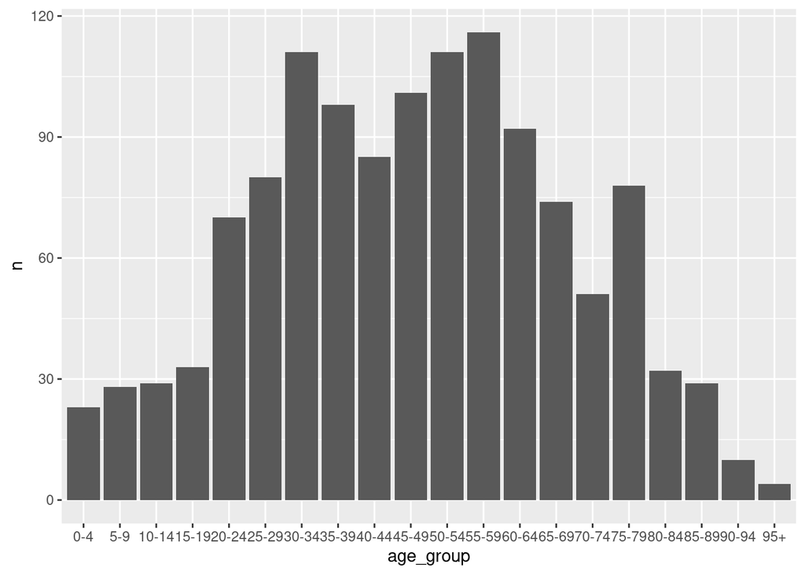

Figure 4: Detected cases by age group and by region.

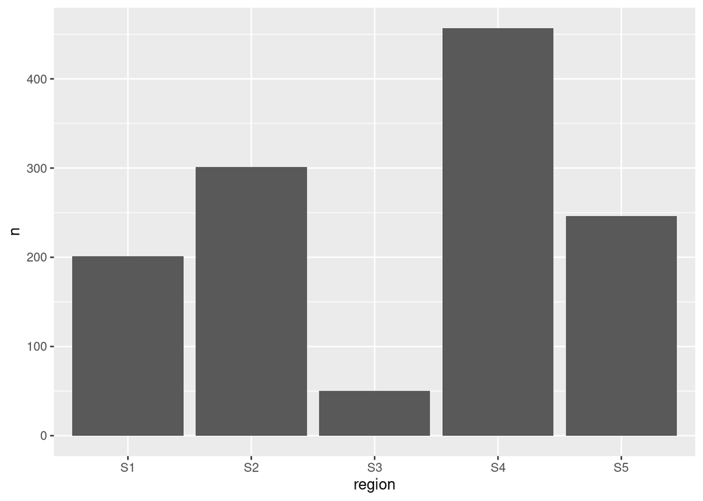

Figure 5: Detected cases by age group and by region.

```r
ll %>% group_by(age_group) %>% summarise(n = n()) %>%
  ggplot(aes(x = age_group, y = n)) +
  geom_col()

ll %>% group_by(region) %>% summarise(n = n()) %>%
  ggplot(aes(x = region, y = n)) +
  geom_col()
```

Counts on their own are misleading, because the age groups and the regions are of very different sizes: the biggest region here has more than ten times the population of the smallest. Dividing by the population turns them into incidence rates, which is what tells us who is actually at greatest risk and where the pressure per head is worst. We use hospitalisations rather than all detected cases, since every hospitalisation is in the line list while milder cases are only sampled.

```r
pop_age <- population_matrix("Sweway", age_breaks = c(0, 20, 45, 65),
                             by_region = FALSE)[, 1]
pop_region <- colSums(population_matrix("Sweway"))

# the line list reports five-year bands; age_mid is the middle of each one, so
# cases can be grouped into whatever bands we have populations for
age_bands <- c("0-19", "20-44", "45-64", "65+")

hosp_by_age <- ll %>% filter(hospitalised == TRUE) %>%
  mutate(band = cut(age_mid, c(0, 20, 45, 65, Inf), right = FALSE,
                    labels = age_bands)) %>%
  group_by(band) %>% summarise(n = n()) %>%
  mutate(population = pop_age[as.character(band)],
         per_100k = 1e5 * n / population)
hosp_by_age
```

```
# A tibble: 4 × 4
  band      n population per_100k
  <fct> <int>      <dbl>    <dbl>
1 0-19      5     720609    0.694
2 20-44    26    1125529    2.31
3 45-64    68     719078    9.46
4 65+     106     550951   19.2
```

```r
ggplot(hosp_by_age, aes(x = band, y = per_100k)) +
  geom_col() +
  labs(x = NULL, y = "Hospitalisations per 100,000")

hosp_by_region <- ll %>% filter(hospitalised == TRUE) %>%
  group_by(region) %>% summarise(n = n()) %>%
  mutate(population = pop_region[as.character(region)],
         per_100k = 1e5 * n / population)
hosp_by_region
```

```
# A tibble: 5 × 4
  region     n population per_100k
  <fct>  <int>      <dbl>    <dbl>
1 S1        40     181599    22.0
2 S2        57     581963     9.79
3 S3         7     117303     5.97
4 S4        68    1407806     4.83
5 S5        33     827496     3.99
```

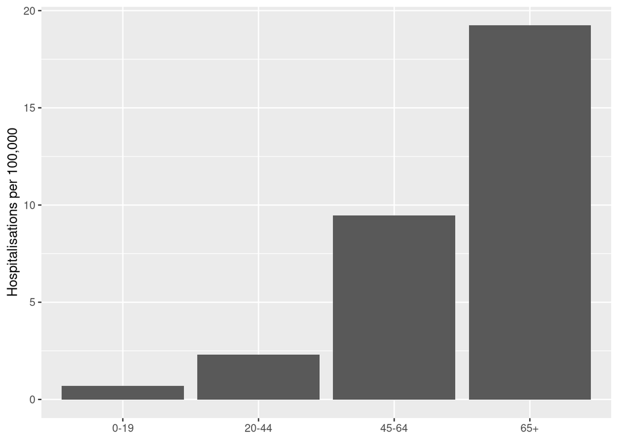

Figure 6: Hospitalisations per 100,000 people, by age group and by region.

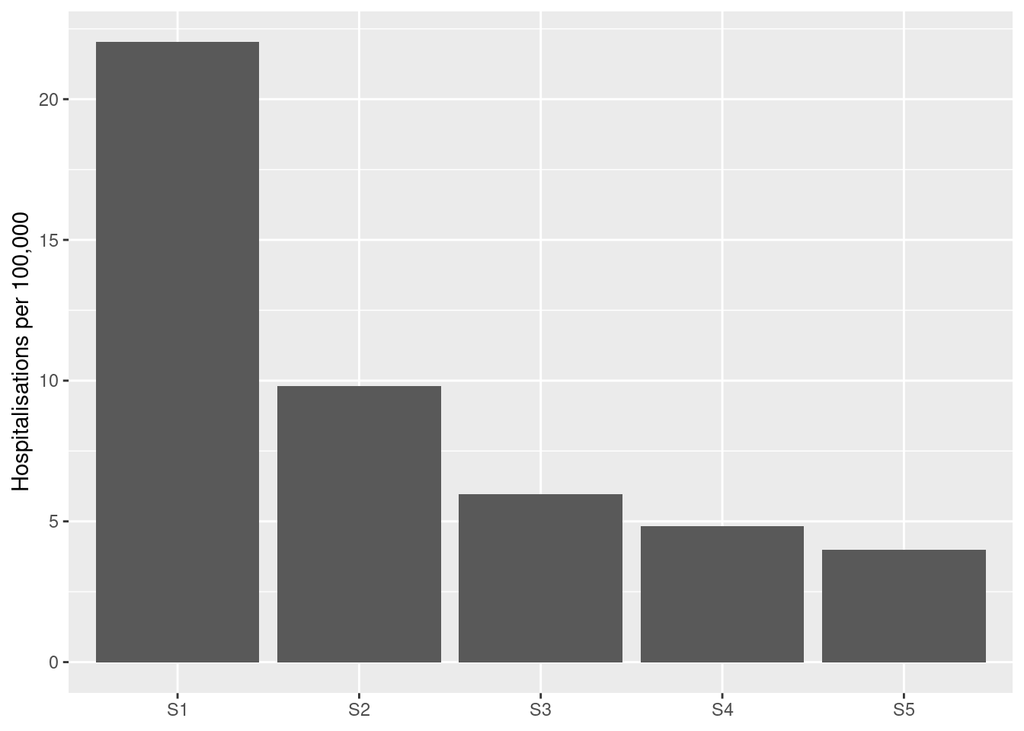

Figure 7: Hospitalisations per 100,000 people, by age group and by region.

```r
ggplot(hosp_by_region, aes(x = region, y = per_100k)) +
  geom_col() +
  labs(x = NULL, y = "Hospitalisations per 100,000")
```

The regional picture changes more than that — it reverses. The region with the most cases is simply the one with the most people, while the highest rate per head is where the outbreak started, which is some way ahead of the rest. Counts tell you where the beds are needed now; rates tell you where the epidemic is in its course.

## Simulating an influenza outbreak with seirvax

[`examples/01_single_population.R`](https://github.com/Gulfa/modelling_prep_ex/blob/main/examples/01_single_population.R) and [`examples/02_age_structured.R`](https://github.com/Gulfa/modelling_prep_ex/blob/main/examples/02_age_structured.R) build up the same model step by step, with more detail on each argument.

A model needs to know how many people there are, how they are grouped, and how they mix. We start by defining the population matrix for Sweway and a social contact matrix. For now we treat the country as a single population, with four age groups.

Population matrix:

```r
N <- population_matrix("Sweway", age_breaks = c(0, 20, 45, 65), by_region = FALSE)
N
```

```
       Sweway
0-19   720609
20-44 1125529
45-64  719078
65+    550951
```

Mixing matrix: the number of contacts per day between age groups. There is no contact survey for Sweway, so we borrow the POLYMOD survey ([Mossong et al. 2008](https://doi.org/10.1371/journal.pmed.0050074)) from the United Kingdom, aggregated to the same four age groups.

```r
library(socialmixr)
M <- contact_matrix(polymod, countries = "United Kingdom",
                    age.limits = c(0, 20, 45, 65), symmetric = TRUE)
M$matrix
```

```
      contact.age.group
         [0,20)  [20,45)  [45,65)       65+
  [1,] 7.883663 4.047242 1.487512 0.6125562
  [2,] 2.827779 5.667742 2.673422 0.8778406
  [3,] 1.504416 3.869800 3.178423 1.2418862
  [4,] 0.937180 1.922235 1.878675 1.7142857
```

With the population and mixing matrices in hand we can build a model. Besides those, it needs the natural history of the disease (how long people are latent and infectious), how likely each age group is to be hospitalised, and how many infections to start with.

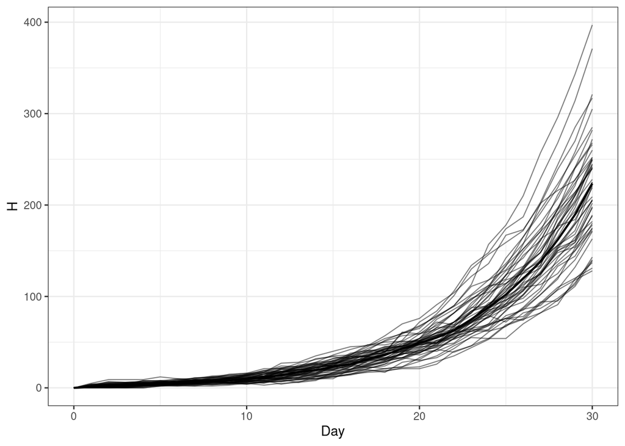

Figure 8: Hospital occupancy over 30 days, 100 stochastic simulations.

```r
model <- build_model(N = N, R0 = 1.5, C_age = M$matrix,
                     p_hosp = c(0.01, 0.02, 0.05, 0.1),
                     latent_period = 1, infectious_period = 2, I0 = 20)

res <- run_model(model, "stochastic", t_max = 30, n_sim = 100, seed = 1)
plot(res, var = "H")
```

### Fitting R0 to the observed admissions

[`examples/05_fitting.R`](https://github.com/Gulfa/modelling_prep_ex/blob/main/examples/05_fitting.R) covers the fitting machinery in more depth: what each method does, how to change the priors, trace plots and other diagnostics, and what the uncertainty in a projection does and does not include.

Rather than guessing R0, we can estimate it from the observed admissions using the same model. Two methods are shown: `optim`, which gives a quick point estimate, and `pmcmc`, which runs a particle filter so that the estimate accounts for the randomness of the epidemic as well as the noise in the data. Particle MCMC is explained, with worked examples in R, in Endo, van Leeuwen and Baguelin, [*Introduction to particle Markov-chain Monte Carlo for disease dynamics modellers*](https://doi.org/10.1016/j.epidem.2019.100363), Epidemics 29 (2019).

Note that we have assumed values for `I0` and `p_hosp`, and that these will obviously affect the fit: a model that assumes a lower probability of hospitalisation needs more infections, and so a higher R0, to produce the same number of admissions.

```r
data <- hosp_inc %>%
  mutate(time = as.numeric(date_hospital - min(date_hospital)) + 1,
         admissions = I) %>%
  select(time, admissions)

observed_age_dist <- ll[hospitalised == TRUE,
                        .N, by = .(band = cut(age_mid, c(0, 20, 45, 65, Inf),
                                              right = FALSE,
                                              labels = c("0-19", "20-44",
                                                         "45-64", "65+")))]
fit1 <- fit_model(model, data, pars = "R0", method = "optim")
fit1
```

```
<seirvax_fit> method: optim
  Data: 27 day(s) of admissions, 1 series (all)
  Log posterior at estimate: -63.36
  Estimates (maximum a posteriori, approx. 95% interval):
 parameter estimate lower upper
        R0    1.463 1.425 1.502
  Fitted model: fit$model; see also plot(fit) and project_fit()
```

```r
fit3 <- fit_model(model, data, pars = "R0", method = "pmcmc",
                  n_steps = 300, n_chains = 1, n_particles = 100, dt = 0.25,
                  n_threads = 4, seed = 1)
fit3
```

```
<seirvax_fit> method: pmcmc
  Data: 27 day(s) of admissions, 1 series (all)
  MCMC: 1 chain(s) x 225 step(s) after burn-in; acceptance 0.71
  Particle filter: 100 particles, dt = 0.25
  Estimates (posterior median, 95% credible interval):
 parameter estimate lower upper
        R0    1.441 1.366 1.516
  Fitted model: fit$model; see also plot(fit) and project_fit()
```

The fitted model can be compared with the data it was fitted to, and with the age distribution of admissions, which the fit never saw:

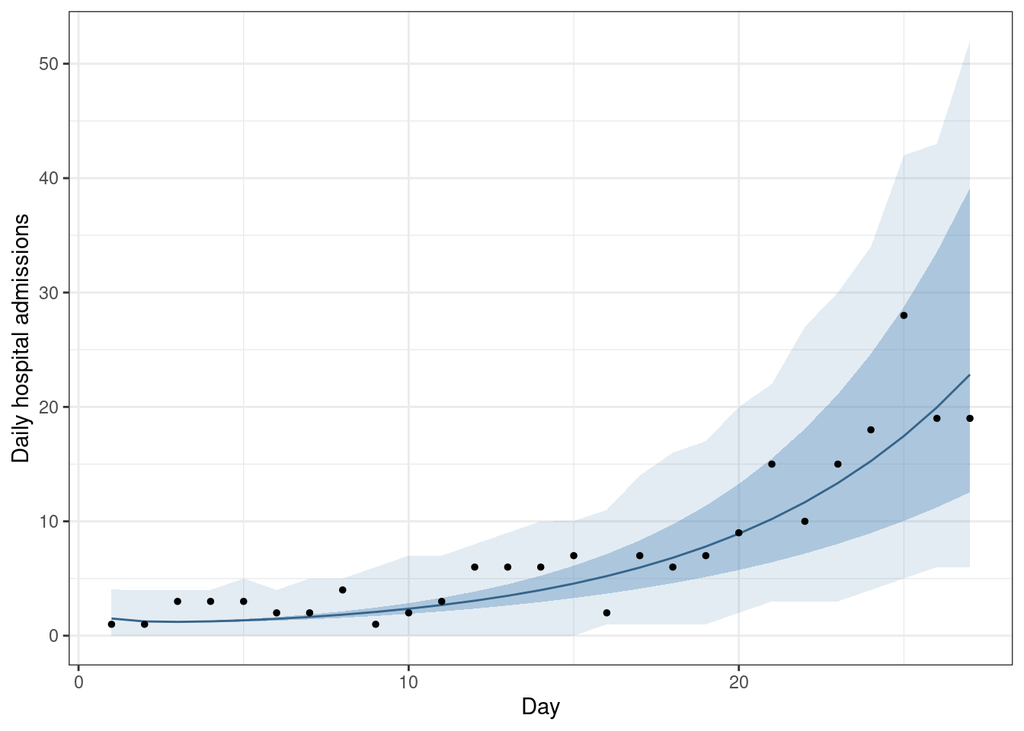

Figure 9: The fitted model against the observed admissions.

```r
plot(fit3, seed = 1)
```

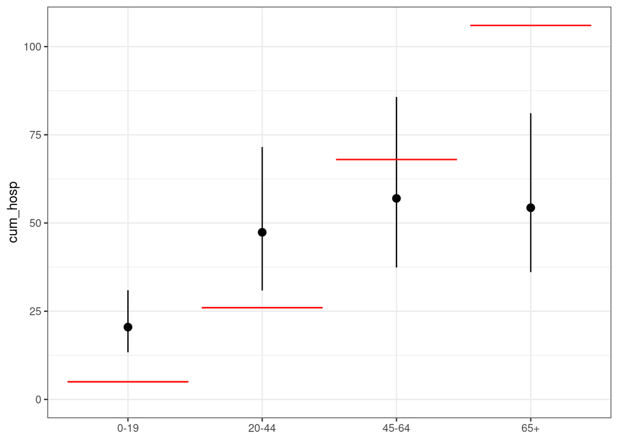

Figure 10: Modelled hospital admissions by age group (points and intervals) against the observed numbers (red).

```r
plot(fit3, type = "distribution", by = "age", measure = "cum_hosp", seed = 1) +
  geom_errorbar(aes(x = band, y = N, ymin = N, ymax = N),
                data = observed_age_dist, color = "red")
```

The match is poor, because of the assumed values for the hospitalisation probabilities and the borrowed age-based mixing matrix. Fitting R0 pins down how fast the epidemic grows, but it cannot correct the age pattern: that comes entirely from `p_hosp` and the contact matrix. Improving it means revisiting those assumptions rather than the fit.

## Scenarios

[`examples/04_scenarios.R`](https://github.com/Gulfa/modelling_prep_ex/blob/main/examples/04_scenarios.R) compares a set of scenarios in a few lines, and [`examples/03_age_and_region.R`](https://github.com/Gulfa/modelling_prep_ex/blob/main/examples/03_age_and_region.R) shows the difference between scaling contacts with `beta_schedule` and changing the mixing pattern with `mixing_schedule`.

With a fitted model we can project forward and ask what different measures would do. Projections start where the data ends and carry the fit’s uncertainty: each posterior draw is run separately, and for a `pmcmc` fit each one continues from the state the particle filter reached, so the projection follows the epidemic that was actually observed.

The baseline is the fitted model with nothing changed:

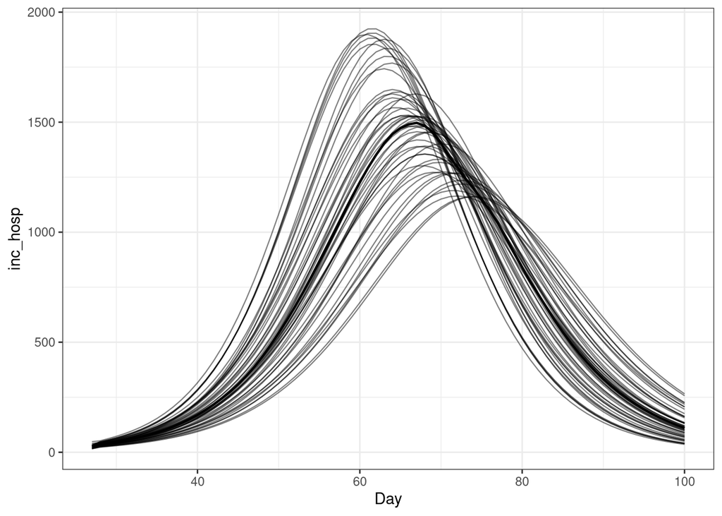

Figure 11: Projected daily hospital admissions under the baseline, one line per posterior draw.

```r
proj <- project_fit(fit3, t_max = 100, n_draws = 50, seed = 1)
plot(proj, var = "inc_hosp")
```

The first scenario reduces contacts across the board by 30% from day 40, as a broad distancing measure would:

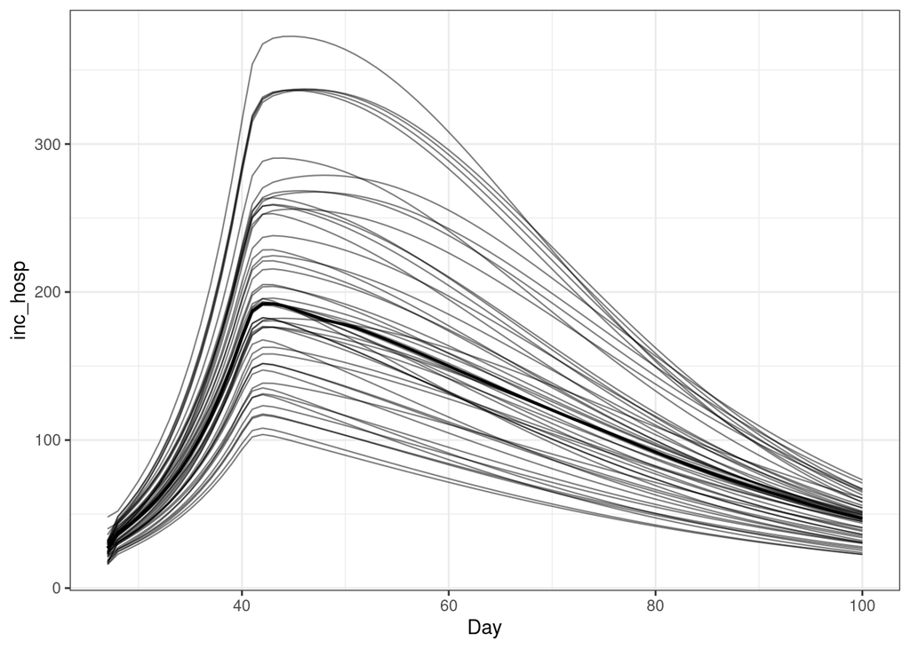

Figure 12: Projection with contacts reduced by 30% from day 40.

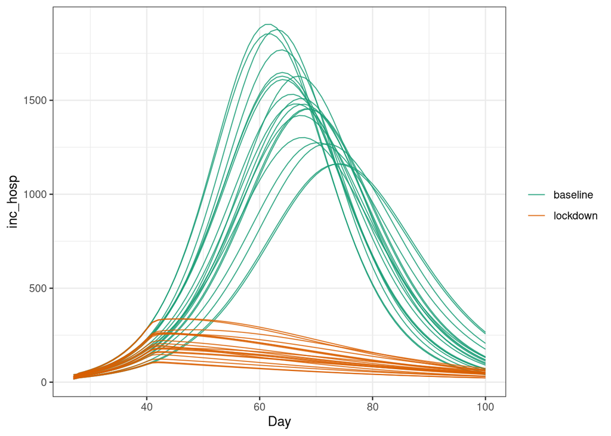

Figure 13: Projection with contacts reduced by 30% from day 40.

```r
lockdown <- update_model(fit3$model,
                         beta_schedule = data.frame(time = 40, mult = 0.7))

proj2 <- project_fit(fit3, model = lockdown, t_max = 100, n_draws = 50,
                     seed = 1)
plot(proj2, var = "inc_hosp")

comp <- compare_scenarios(list(baseline = proj, lockdown = proj2))
plot(comp, var = "inc_hosp", style = "spaghetti")
```

The second scenario leaves the overall contact rate alone and changes who meets whom: contacts involving the over-65s are halved from day 40, as shielding of the most vulnerable group would. This is a change to the mixing matrix rather than a multiplier on transmission.

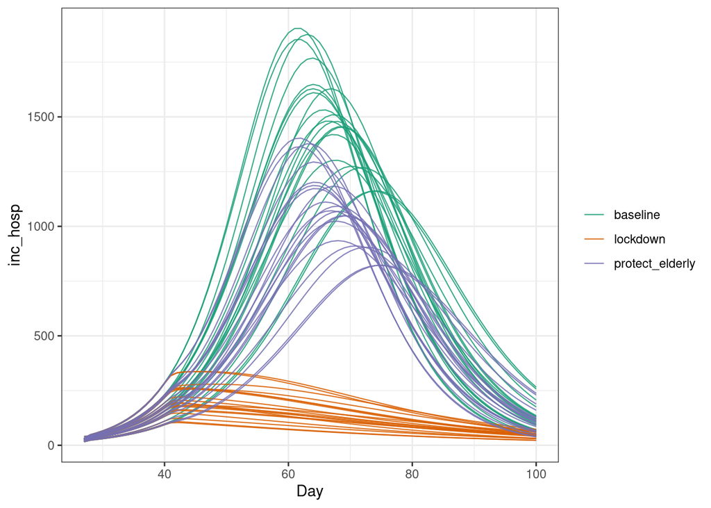

Figure 14: Projection with contacts involving the over-65s halved from day 40, and all three scenarios together.

```r
protect_elderly_mm <- M$matrix
protect_elderly_mm[, 4] <- protect_elderly_mm[, 4] * 0.5
protect_elderly_mm[4, 1:3] <- protect_elderly_mm[4, 1:3] * 0.5

model_protect_elderly <- update_model(
  fit3$model,
  mixing_schedule = list(list(time = 40, C_age = protect_elderly_mm)))

proj3 <- project_fit(fit3, model = model_protect_elderly, t_max = 100,
                     n_draws = 50, seed = 1)

comp2 <- compare_scenarios(list(baseline = proj, lockdown = proj2,
                                protect_elderly = proj3))
plot(comp2, var = "inc_hosp", style = "spaghetti")
```

Finally, the total number of hospital admissions under each scenario, with the uncertainty carried through from the fit:

```r
summary(comp2)[measure == "cum_hosp"]
```

```
          scenario  measure     mean    median     lower    upper
1:        baseline cum_hosp 46868.28 46989.966 40230.277 53049.02
2:        lockdown cum_hosp  9103.02  8488.337  4606.428 15129.03
3: protect_elderly cum_hosp 36059.29 36139.920 30226.173 41506.83
```

## Adding regions

[`examples/03_age_and_region.R`](https://github.com/Gulfa/modelling_prep_ex/blob/main/examples/03_age_and_region.R) sets out the age × region structure, and [`examples/06_country_data.R`](https://github.com/Gulfa/modelling_prep_ex/blob/main/examples/06_country_data.R) covers the bundled population data, the distances between regions and the maps.

So far the whole country has been treated as one well-mixed population. The line list, though, records which region each case is in, and the outbreak clearly did not start everywhere at once. A regional model lets us ask where hospital pressure will fall, and whether restricting travel between regions would help.

The population matrix now keeps the regions instead of pooling them, giving one column per region:

```r
N_reg <- population_matrix("Sweway", age_breaks = c(0, 20, 45, 65))
N_reg
```

```
         S1     S2    S3     S4     S5
0-19  38971 134128 27538 309870 210102
20-44 48367 181661 28344 588507 278650
45-64 49018 143773 30591 305795 189901
65+   45243 122401 30830 203634 148843
```

We also need to say how much people mix between regions. There is no travel survey for Sweway, so we assume that most contacts happen at home and that the rest fall off with distance between the regional centres. Two numbers carry the assumption: the share of contacts made in a person’s own region, and the distance scale over which the remainder spreads.

```r
dist <- region_distances(country = "Sweway")
round(dist)
```

```
    S1  S2  S3  S4  S5
S1   0  74 108 158 159
S2  74   0 142  95 122
S3 108 142   0 169 126
S4 158  95 169   0  65
S5 159 122 126  65   0
```

```r
within <- 0.95        # share of contacts made in the home region
scale_km <- 100       # distance scale for the rest

w <- exp(-dist / scale_km)
diag(w) <- 0
M_region <- (1 - within) * w / rowSums(w)
diag(M_region) <- within
round(M_region, 3)
```

```
      S1    S2    S3    S4    S5
S1 0.950 0.019 0.014 0.008 0.008
S2 0.017 0.950 0.009 0.014 0.011
S3 0.016 0.012 0.950 0.009 0.014
S4 0.008 0.015 0.007 0.950 0.020
S5 0.008 0.011 0.011 0.020 0.950
```

### Where the outbreak started

In the national model it was enough to say how many infections to start with. With regions we have to say *where* they were, and that choice drives the whole regional picture. The line list tells us: the region with the earliest onsets, and the most cases in the first days, is where the outbreak took hold first.

```r
first_cases <- ll[, .(first_onset = min(date_onset),
                      early_cases = sum(date_onset < min(ll$date_onset) + 10),
                      total = .N), by = region][order(first_onset, -early_cases)]
first_cases
```

```
   region first_onset early_cases total
1:     S1  2026-01-02          20   201
2:     S4  2026-01-03          18   457
3:     S2  2026-01-04           4   301
4:     S3  2026-01-04           2    50
5:     S5  2026-01-05           9   246
```

```r
seed_region <- as.character(first_cases$region[1])

# all initial infections in working-age adults in that region, and nowhere else
I0_reg <- matrix(0, nrow(N_reg), ncol(N_reg), dimnames = dimnames(N_reg))
I0_reg["20-44", seed_region] <- 30
I0_reg
```

```
      S1 S2 S3 S4 S5
0-19   0  0  0  0  0
20-44 30  0  0  0  0
45-64  0  0  0  0  0
65+    0  0  0  0  0
```

### Fitting the regional model

The model is built exactly as before, with the region mixing matrix and the explicit seeding added. We fit R0 to the same national admissions series, so the regional distribution is something the fit never sees and can be used to check the travel assumption.

```r
model_reg <- build_model(N = N_reg, R0 = 1.5, C_age = M$matrix,
                         M_region = M_region,
                         p_hosp = c(0.01, 0.02, 0.05, 0.1),
                         latent_period = 1, infectious_period = 2, I0 = I0_reg)

fit_reg <- fit_model(model_reg, data, pars = "R0", method = "pmcmc",
                     n_steps = 300, n_chains = 1, n_particles = 100, dt = 0.25,
                     n_threads = 4, seed = 1)
fit_reg
```

```
<seirvax_fit> method: pmcmc
  Data: 27 day(s) of admissions, 1 series (all)
  MCMC: 1 chain(s) x 225 step(s) after burn-in; acceptance 0.62
  Particle filter: 100 particles, dt = 0.25
  Estimates (posterior median, 95% credible interval):
 parameter estimate lower upper
        R0     1.41 1.337 1.482
  Fitted model: fit$model; see also plot(fit) and project_fit()
```

```
   region  measure      mean    median     lower     upper share_mean
1:     S1 cum_hosp 63.995069 61.897747 44.138824 85.203650 0.41325192
2:     S2 cum_hosp 28.573332 27.374929 18.123956 40.158511 0.18331257
3:     S3 cum_hosp  5.843311  5.597677  3.703559  8.216688 0.03748555
4:     S4 cum_hosp 35.614027 34.079042 22.379761 50.363885 0.22831320
5:     S5 cum_hosp 21.469952 20.544092 13.489025 30.365699 0.13763676
   share_median share_lower share_upper
1:   0.41405356   0.3975761  0.43354475
2:   0.18311688   0.1779439  0.18738622
3:   0.03744408   0.0363620  0.03834042
4:   0.22796179   0.2197181  0.23500604
5:   0.13742369   0.1324313  0.14169127
```

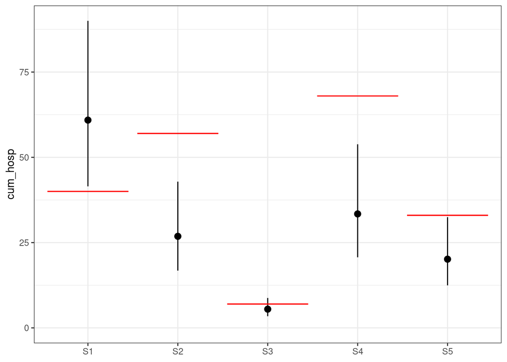

Figure 15: Modelled hospital admissions by region over the period covered by the data (points and intervals) against the observed numbers (red).

```r
observed_region_dist <- ll[hospitalised == TRUE, .N, by = .(region)]

plot(fit_reg, type = "distribution", by = "region", measure = "cum_hosp") +
  geom_errorbar(aes(x = region, y = N, ymin = N, ymax = N),
                data = observed_region_dist, color = "red")

project_summary(fit_reg, by = "region", t_max = max(data$time),
                measures = "cum_hosp", n_draws = 50, seed = 1)
```

### Scenario: restricting travel between regions

The natural question for a regional model is whether cutting travel helps. We reduce cross-regional contacts five-fold from day 40 by swapping in a mixing matrix with a higher share of contacts at home, and for contrast impose the same restriction immediately, at the end of the data.

```
          scenario  measure     mean   median    lower    upper
1:        baseline cum_hosp 45210.97 45121.53 37878.99 50287.34
2: restrict_day_40 cum_hosp 45156.88 45099.96 37614.45 50320.83
3:    restrict_now cum_hosp 44878.49 44791.47 37119.09 50186.25
```

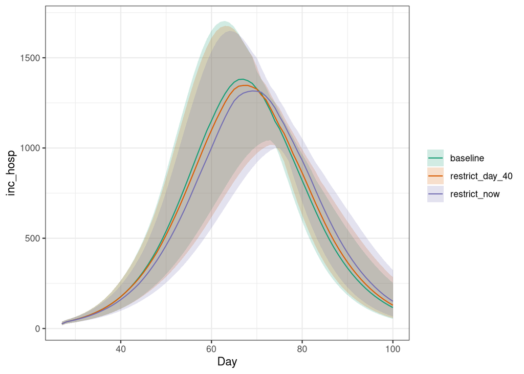

Figure 16: Daily hospital admissions under the baseline and under reduced travel between all regions, imposed immediately or from day 40.

```r
restricted <- function(within) {
  m <- (1 - within) * w / rowSums(w)
  diag(m) <- within
  m
}

day40 <- update_model(fit_reg$model,
                      mixing_schedule = list(list(time = 40,
                                                  M_region = restricted(0.99))))
immediate <- update_model(fit_reg$model,
                          mixing_schedule = list(list(time = max(data$time),
                                                      M_region = restricted(0.99))))

proj_reg <- project_fit(fit_reg, t_max = 100, n_draws = 50, seed = 1)
proj_day40 <- project_fit(fit_reg, model = day40, t_max = 100, n_draws = 50,
                          seed = 1)
proj_now <- project_fit(fit_reg, model = immediate, t_max = 100, n_draws = 50,
                        seed = 1)

comp_reg <- compare_scenarios(list(baseline = proj_reg,
                                   restrict_day_40 = proj_day40,
                                   restrict_now = proj_now))
plot(comp_reg, var = "inc_hosp")
summary(comp_reg)[measure == "cum_hosp"]
```

Neither restriction makes much difference, and that is the point. By the end of the data every region already has its own established epidemic, so almost all transmission is within regions and there is little left for a travel restriction to prevent. Travel measures matter while an outbreak is still confined to where it started, and in this outbreak that window closed in the first three weeks, before our data even ended.

### What if one region had been cut off early?

To see what travel restrictions can do, they have to be in place before the region is seeded. That cannot be a projection: projections start from the state at the end of the data, which already has the epidemic everywhere. Instead we re-run the fitted model from day 0 under a different travel assumption, and compare it with the fitted baseline.

We isolate the region furthest from where the outbreak started, cutting its contacts with every other region to a hundredth of normal. Rows of a mixing matrix have to sum to 1, so the matrix is renormalised afterwards.

```r
isolate_region <- function(M, region, factor = 0.01) {
  other <- setdiff(rownames(M), region)
  M[region, other] <- M[region, other] * factor
  M[other, region] <- M[other, region] * factor
  M / rowSums(M)                       # rows must still sum to 1
}

far_region <- names(which.max(dist[seed_region, ]))
far_region
```

```
[1] "S5"
```

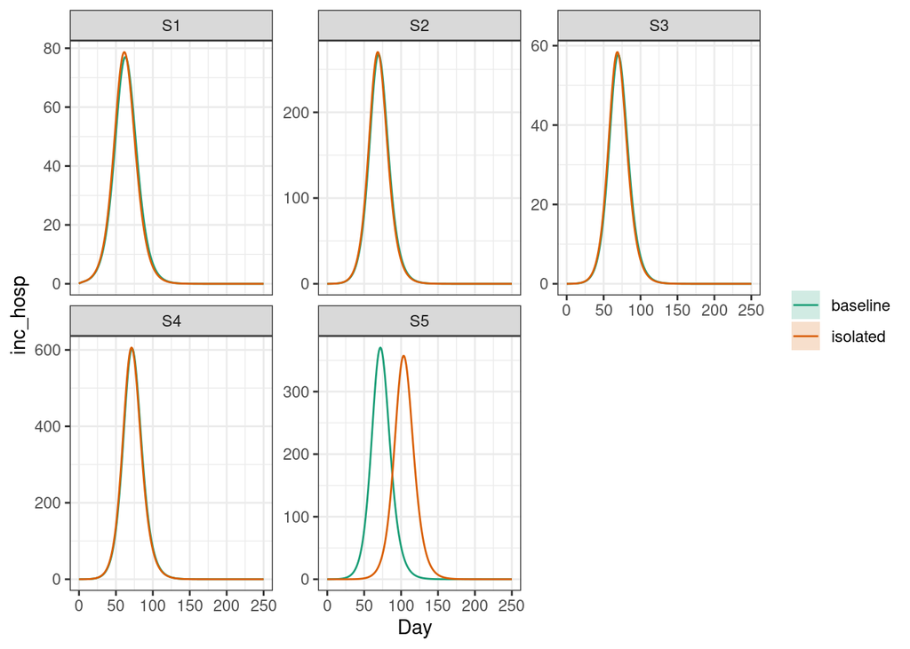

Figure 17: Daily hospital admissions by region, with and without one region cut off from the start.

```r
isolated <- update_model(
  fit_reg$model,
  mixing_schedule = list(list(time = 0,
                              M_region = isolate_region(M_region, far_region))))

comp_iso <- compare_scenarios(list(baseline = fit_reg$model, isolated = isolated),
                              t_max = 250)
plot(comp_iso, var = "inc_hosp", by = "region")
```

```r
dcast(summary(comp_iso, by = "region")[measure %in% c("cum_hosp", "peak_hosp_day",
                                                      "peak_hosp_occupancy")],
      region + measure ~ scenario, value.var = "value")
```

```
    region             measure   baseline   isolated
 1:     S1            cum_hosp  2985.3998  2985.4390
 2:     S1       peak_hosp_day    68.0000    67.0000
 3:     S1 peak_hosp_occupancy   492.5460   501.5480
 4:     S2            cum_hosp  8976.8607  8976.8703
 5:     S2       peak_hosp_day    75.0000    74.0000
 6:     S2 peak_hosp_occupancy  1673.3474  1686.9637
 7:     S3            cum_hosp  1934.9080  1934.9103
 8:     S3       peak_hosp_day    75.0000    74.0000
 9:     S3 peak_hosp_occupancy   361.1966   364.4616
10:     S4            cum_hosp 19671.7409 19671.7514
11:     S4       peak_hosp_day    77.0000    76.0000
12:     S4 peak_hosp_occupancy  3756.0365  3766.2777
13:     S5            cum_hosp 12077.8804 12077.7070
14:     S5       peak_hosp_day    77.0000   109.0000
15:     S5 peak_hosp_occupancy  2304.3115  2236.5478
```

The effect falls on that region alone: its epidemic is delayed by weeks and its peak is slightly lower, while the other regions are unchanged. What isolation does not do is reduce the total number of admissions there. Once even a handful of infections get through, a region with R0 above one has its own epidemic, and that epidemic reaches much the same final size whenever it starts. Cutting travel buys time — to prepare hospitals, or to vaccinate — rather than preventing cases, and it only buys time if it is in place before the virus arrives.

## Vaccination

[`examples/08_vaccination.R`](https://github.com/Gulfa/modelling_prep_ex/blob/main/examples/08_vaccination.R) compares vaccine effects, ways of targeting doses and the timing of campaigns in more detail.

The model can vaccinate in two ways: an initial coverage, `vacc_coverage`, for people vaccinated before the epidemic, and a schedule, `vacc_schedule`, giving doses per day from a chosen time. We look at each in turn.

### Before the outbreak

Suppose the over-65s had been offered a seasonal vaccine before the outbreak, and 80% had taken it. The vaccine is assumed to protect 40% against infection and to do nothing beyond that: a vaccinated person who does get infected is as likely to be admitted as anyone else their age.

An initial coverage cannot be added to a projection: a projection continues from the state at the end of the data, in which nobody is vaccinated, and changing `vacc_coverage` there has no effect. Instead, as with the isolated region, we re-run the fitted national model from day 0, once as fitted and once with the vaccine. `from = 0` keeps the uncertainty in R0 from the fit.

```r
vaccinated <- update_model(fit3$model, vacc_coverage = c(0, 0, 0, 0.8),
                           ve_infection = 0.4)
c(baseline = R_eff(fit3$model), vaccinated = R_eff(vaccinated))
```

```
  baseline vaccinated
  1.441109   1.426240
```

```r
proj_novacc <- project_fit(fit3, from = 0, t_max = 100, n_draws = 50, seed = 1)
proj_vacc <- project_fit(fit3, model = vaccinated, from = 0, t_max = 100,
                         n_draws = 50, seed = 1)
comp_vacc <- compare_scenarios(list(baseline = proj_novacc,
                                    vaccinated = proj_vacc))
summary(comp_vacc)[measure %in% c("cum_infections", "cum_hosp")]
```

```
     scenario        measure       mean     median      lower      upper
1:   baseline       cum_hosp   46356.85   46658.46   38837.69   53013.74
2: vaccinated       cum_hosp   39551.82   39874.28   32338.36   45813.30
3:   baseline cum_infections 1465934.35 1473464.05 1267492.27 1642995.95
4: vaccinated cum_infections 1364897.04 1373866.59 1158585.79 1544400.89
```

```r
summary(comp_vacc, by = "age")[measure == "cum_hosp"]
```

```
     scenario   age  measure      mean    median     lower     upper
1:   baseline  0-19 cum_hosp  4265.912  4293.688  3723.174  4720.602
2: vaccinated  0-19 cum_hosp  4150.283  4184.360  3549.588  4640.445
3:   baseline 20-44 cum_hosp 11390.777 11467.536  9715.493 12833.441
4: vaccinated 20-44 cum_hosp 10958.702 11051.575  9130.819 12497.933
5:   baseline 45-64 cum_hosp 15023.487 15123.315 12575.159 17184.594
6: vaccinated 45-64 cum_hosp 14246.252 14365.226 11623.370 16516.377
7:   baseline   65+ cum_hosp 15676.674 15773.924 12823.864 18275.099
8: vaccinated   65+ cum_hosp 10196.584 10273.121  8034.579 12158.549
```

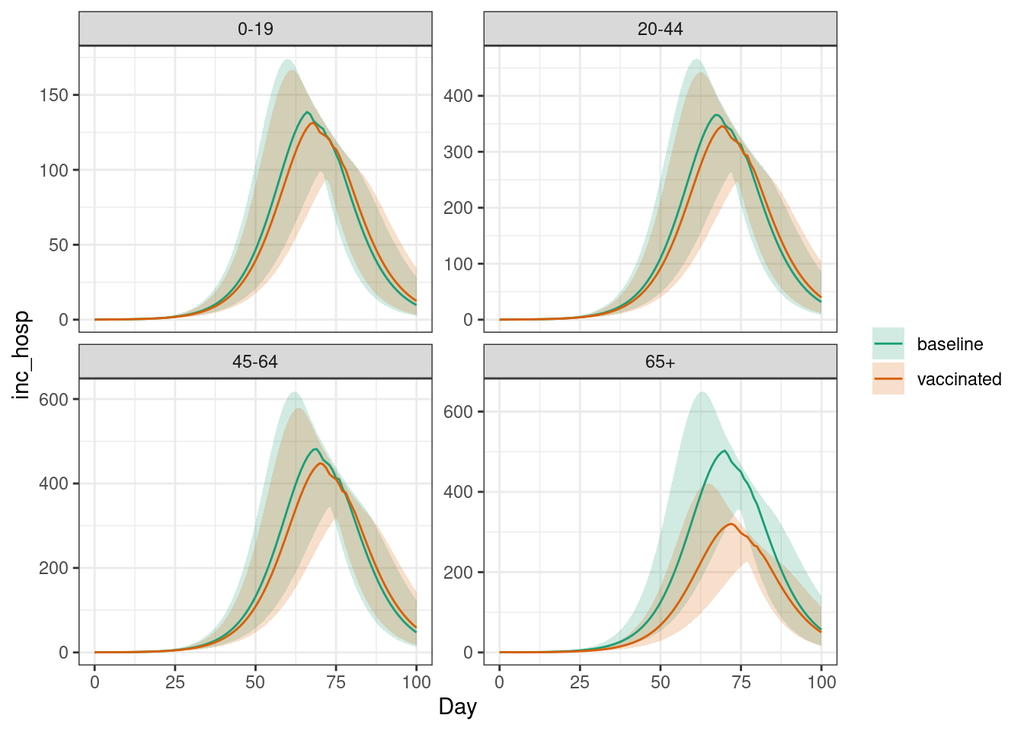

Figure 18: Daily hospital admissions by age group, with and without 80% of the over-65s vaccinated (VE 40% against infection) before the outbreak.

```r
plot(comp_vacc, var = "inc_hosp", by = "age")
```

Vaccinating the over-65s barely changes R_eff: they make few of the contacts that spread the virus, so the epidemic as a whole is hardly smaller. Admissions fall by about 15%, though, and most of the fall is among the over-65s themselves, whose admissions drop by about a third, because that is where admissions are concentrated. The younger age groups gain a little, indirectly, from the slightly smaller epidemic.

The intervals of the two scenarios overlap, but mostly because both carry the same uncertainty about R0. The two projections use the same posterior draws (the same `seed`), so the difference can be taken draw by draw, which gives the uncertainty in the number of admissions averted:

```r
total_hosp <- function(proj) {
  get_output(proj, "cum_hosp")[time == max(time), value]   # one per draw
}
averted <- total_hosp(proj_novacc) - total_hosp(proj_vacc)
round(quantile(averted, c(0.025, 0.5, 0.975)))
```

```
 2.5%   50% 97.5%
 6499  6784  7200
```

The vaccine averts roughly 6,500 to 7,200 admissions over the epidemic, a far narrower range than the totals themselves suggest: whatever R0 turns out to be, the vaccine’s effect is much the same. A vaccine that also protected against severe disease in those it fails to protect from infection (`ve_hosp`) would avert more, without changing the epidemic any further.

### Vaccinating now

The decision actually open at the end of the data is whether to vaccinate now. That is a vaccination schedule starting on the last day of the data, which a projection can carry, because it changes what happens from then on. Suppose the same doses, enough for 80% of the over-65s, can be given over two weeks. Doses go to everyone over 65 who is not ill, including those who have already had influenza, for whom they are wasted.

```r
doses_65 <- 0.8 * N["65+", 1]
vaccinate_now <- update_model(
  fit3$model, ve_infection = 0.4,
  vacc_schedule = data.frame(time = max(data$time) + c(0, 14),
                             doses = c(doses_65 / 14, 0), age = "65+"))
vaccinate_now
```

```
<seirvax_model>
  4 age group(s) x 1 region(s); population 3,116,167
  Age groups: 0-19, 20-44, 45-64, 65+
  Regions:    Sweway
  R0 = 1.44, beta = 0.06062, R_eff(0) = 1.44
  Latent period 1 days, infectious period 2 days
  Initial infected: 80 (I0 + E0); vaccinated: 0
  Vaccination: 0 doses/day from day 0, 31,483 doses/day from day 27, 0 doses/day from day 41
  Parameters by age (averaged over regions, population-weighted):
                 0-19 20-44 45-64 65+
susceptibility   1    1     1     1
transmissibility 1    1     1     1
p_hosp           0.01 0.02  0.05  0.1
p_death_hosp     0    0     0     0
p_death_comm     0    0     0     0
vacc_coverage    0    0     0     0
ve_infection     0.4  0.4   0.4   0.4
ve_transmission  0    0     0     0
ve_hosp          0    0     0     0
ve_death         0    0     0     0
```

```r
proj_now_vacc <- project_fit(fit3, model = vaccinate_now, t_max = 100,
                             n_draws = 50, seed = 1)
comp_now_vacc <- compare_scenarios(list(baseline = proj,
                                        vaccinate_now = proj_now_vacc))
averted_now <- total_hosp(proj) - total_hosp(proj_now_vacc)
round(quantile(averted_now, c(0.025, 0.5, 0.975)))
```

```
 2.5%   50% 97.5%
 5958  6509  7018
```

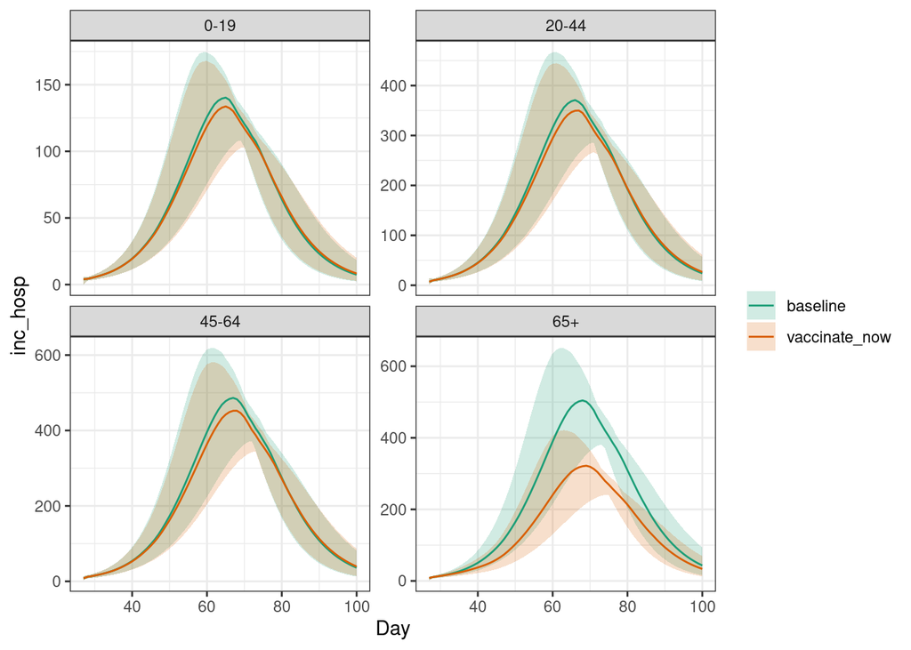

Figure 19: Projected daily hospital admissions by age group, with and without vaccinating the over-65s over two weeks from the end of the data.

```r
plot(comp_now_vacc, var = "inc_hosp", by = "age")
```

Vaccinating over the two weeks after the data ends averts nearly as many admissions as vaccinating before the outbreak. At the end of the data the outbreak has barely begun — about 200 of the tens of thousands of projected admissions have happened — so few of the over-65s have been infected yet, few doses are wasted on them, and the vaccine is in place before most of the epidemic arrives. That window does not stay open: in [`examples/08_vaccination.R`](https://github.com/Gulfa/modelling_prep_ex/blob/main/examples/08_vaccination.R), the same campaign started at the peak averts less than a quarter as much.